# CD705: Exercises, Week 3

21 October 2026

# Exercise 1

The Week 3.1 R lecture companion shows examples how to test the hypothesis phyp = 0.5 and how to find approximately a 95% confidence interval, using the number of successes in a sample of size n = 10 selected from a binomial distribution with probability of success p = 0.2.

Modify the code to investigate the following questions and write down your conclusions. You should make several runs with independently selected samples to ensure that your conclusions are reliable.

1. For hypothesis testing with fixed phyp = 0.5 and p = 0.2, how do the changes of n affect the results?
2. For hypothesis testing with fixed phyp = 0.5 and n = 10, how do the changes of p affect the results? Answer this question also for n = 5, n = 100 and n = 1000.
3. For hypothesis testing with fixed p = 0.2 and n = 10, how do the changes of phyp affect the results? Answer this question also for n = 5, n = 100 and n = 1000.
4. (optional) Answer the first two questions for a one-tailed hypothesis. Answer the third question for “equally spread” deviations.
5. For confidence intervals with fixed confidence level 1 − α = 95% and p = 0.2, how do the changes of n affect the results? Use any form of a confidence interval you find convenient.
6. For confidence intervals with fixed n = 10 and p = 0.2, how do the changes of the confidence level 1 − α affect the results? Answer this question also for n = 5, n = 100 and n = 1000.

## Solution

Code copied from the Week 3.1 R lecture companion…

```r
test.hypothesis.old <- function(significance.level,sample.size,x.sample,probability.hypothesised){
  expected <- sample.size*probability.hypothesised;
  deviation <- abs(x.sample-expected);
  lower.bound <- expected - deviation;
  upper.bound <- expected + deviation;
  upper.bound <- ifelse( (upper.bound-floor(upper.bound)) < .Machine$double.eps,
                         upper.bound - 1,floor(upper.bound))
  p.value <-
    pbinom(lower.bound,sample.size,probability.hypothesised) +
    1 - pbinom(upper.bound,sample.size,probability.hypothesised);
  return(p.value < significance.level);
}
```

… and modified to answer the questions above…

```r
get.p.value <- function(sample.size, x.sample, probability.hypothesised){
  expected <- sample.size*probability.hypothesised;
  deviation <- abs(x.sample-expected);
  lower.bound <- expected - deviation;
  upper.bound <- expected + deviation;
  upper.bound <- sapply(upper.bound, function(ub) {
    if ((ub-floor(ub)) < .Machine$double.eps) {
      return(ub - 1)
    } else {
      return(floor(ub))
    }
  })

  p.value <-
    pbinom(lower.bound,sample.size,probability.hypothesised) +
    1 - pbinom(upper.bound,sample.size,probability.hypothesised);
  return(p.value);
}

test.hypothesis <- function(significance.level,sample.size,x.sample,probability.hypothesised){
  p.value <- get.p.value(sample.size, x.sample,probability.hypothesised);
  return(p.value < significance.level);
}

get.rejected.hypotheses <- function(alpha, sample.size, x, possible.hypothesis) {
  sapply(x,
    function(x.tmp){
      test.hypothesis(alpha, sample.size, x.tmp, possible.hypothesis)
    }
  )
}
```

```r
df <- data.frame()

p.actual <- 0.5
alpha <- 0.05

sample.size.min <- 5
sample.size.max <- 100
sample.size.num.points <- 50
sample.size.values <-
  floor(seq(sample.size.min, sample.size.max, length.out = sample.size.num.points))

possible.hypothesis.min <- 0
possible.hypothesis.max <- 1
possible.hypothesis.num.points <- 100
possible.hypothesis.values <-
  seq(possible.hypothesis.min, possible.hypothesis.max, length.out = possible.hypothesis.num.points)

for (sample.size in sample.size.values) {
    x <- rbinom(1, sample.size, p.actual)
    rejected.hypotheses <- get.rejected.hypotheses(alpha, sample.size, x, possible.hypothesis.values)
    df <- rbind(df, data.frame(possible.hypothesis.values, rejected.hypotheses, sample.size))
}

#df <- df[df$rejected.hypotheses == 0, ]
str(df)
```

```
## 'data.frame':    5000 obs. of  3 variables:
##  $ possible.hypothesis.values: num  0 0.0101 0.0202 0.0303 0.0404 ...
##  $ rejected.hypotheses       : logi  TRUE TRUE TRUE TRUE TRUE TRUE ...
##  $ sample.size               : num  5 5 5 5 5 5 5 5 5 5 ...
```

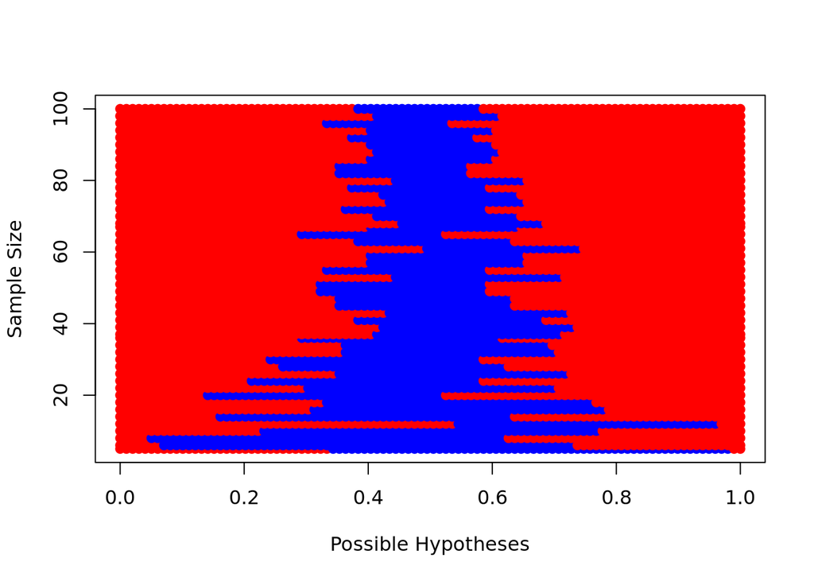

```r
plot(x=df$possible.hypothesis.values,
  y=df$sample.size,
  col=c("blue","red")[df$rejected.hypotheses+1],
  pch=19,
  ylab="Sample Size",
  xlab="Possible Hypotheses"
)
```

As we increase the sample size, we accept the hypothesis for a narrower range of values for p.

Moving on to part (b)…

We want to iterate across a range of values for p and n.

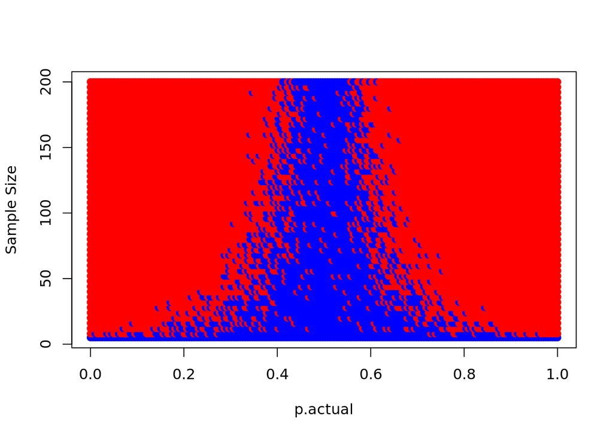

```r
df <- data.frame()

alpha <- 0.05
possible.hypothesis <- 0.5;

sample.size.min <- 5
sample.size.max <- 200
sample.size.num.points <- 50
sample.size.values <-
  floor(seq(sample.size.min, sample.size.max, length.out = sample.size.num.points))

p.actual.min <- 0
p.actual.max <- 1
p.actual.num.points <- 200
p.actual.values <- seq(p.actual.min, p.actual.max, length.out = p.actual.num.points)

for (sample.size in sample.size.values) {
    for (p.actual in p.actual.values) {
        x <- rbinom(1, sample.size, p.actual)
        rejected.hypotheses <- get.rejected.hypotheses(alpha, sample.size, x, possible.hypothesis)
        df <- rbind(df, data.frame(p.actual, rejected.hypotheses, sample.size))
    }
}

plot(x=df$p.actual,
  y=df$sample.size,
  col=c("blue","red")[df$rejected.hypotheses+1],
  pch=19,
  xlab="p.actual",
  ylab="Sample Size"
)
```

For a given hypothesis, as we increase the sample size, we accept the hypothesis for a narrower range of values for p.

Part (c) is similar to part 2, but we iterate across a range of values for p.hypothesised.

Part(f) is very interesting…

For confidence intervals with fixed n = 10 and p = 0.2, how do the changes of the confidence level 1 - $\alpha$ affect the results? Answer this question also for n = 5, n = 100 and n = 1000.

```r
sample.size.min <- 50
sample.size.max <- 1000
sample.size.num.points <- 20
sample.size.values <- seq(sample.size.min, sample.size.max, length.out = sample.size.num.points)

p.actual.min <- 0.01
p.actual.max <- 0.5
p.actual.num.points <- 300
p.actual.values <- seq(p.actual.min, p.actual.max, length.out = p.actual.num.points)

alpha.min <- 0.01
alpha.max <- 0.5
alpha.num.points <- 5
alpha.values <- seq(alpha.min, alpha.max, length.out = alpha.num.points)

df <- data.frame()
possible.hypothesis <- 0.5;
for (sample.size in sample.size.values) {
    for (p.actual in p.actual.values) {
        x <- rbinom(1, sample.size, p.actual)
        for (alpha in alpha.values) {
          rejected.hypotheses <- get.rejected.hypotheses(alpha, sample.size, x, possible.hypothesis)
          df <- rbind(df, data.frame(p.actual, rejected.hypotheses, alpha, sample.size))
        }
    }
}
```

```r
library(plotly)
# I want to remove all rows where rejected.hypotheses is 0
df <- df[df$rejected.hypotheses == 0, ]

plot_ly(
  data = df,
  x = ~p.actual,
  y = ~alpha,
  z = ~sample.size,
  type = "scatter3d",
  mode = "markers",
  color = ~alpha,
  text = ~paste(
    "p.actual:", p.actual,
    "<br>sample.size:", sample.size,
    "<br>alpha:", alpha,
    "<br>Rejected:", rejected.hypotheses
  ),
  hoverinfo = "text",
  marker = list(size = 4)
  #color_continuous_scale=plot_ly.express.colors.sequential.Rainbow
) %>%
  layout(
    scene = list(
      xaxis = list(title = "p.actual"),
      yaxis = list(title = "alpha"),
      zaxis = list(title = "sample.size")
    )
  )
```

[interactive chart not shown]

# Exercise 2

The manufacturer claims that the median lifetime of a component is 25 hours (that means that the lifetime of such a component is equally likely to be below and above 25 hours). To verify this claim, an analyst decided to select a random sample of 20 such components, observe their lifetime and count X, the number of observations exceeding 25 hours.

The sample turned out to contain 8 components with lifetime exceeding 25 hours. Test a suitable hypothesis and state your conclusion.

## Solution

# Exercise 3

One hundred and ten adults resident in a UK area are chosen at random to take part in a survey about personal savings. Forty two of them are found to hold premium bonds. Find a 95% confidence interval for the proportion of adults resident in the UK area who have premium bond holdings.

## Solution

# Exercise 4. (cf. Exercise 14 in Week 2.)

Childhood lead poisoning due to atmospheric pollution is a major public health concern in some areas. A simple random sample of size 10 has been selected and this sample contains: (i) no; (ii) four ; (iii) five children with a high blood lead level.

If you are told that the sample is from

- a group of 100 children, where 20 have a high blood lead level,
- a large population, where 1 child in 5 has a high blood lead level,

would you find this claim plausible? Justify your conclusion.

## Solution

# Exercise 5. (cf. Exercise 16 in Week 2.)

A lecturer selected randomly five students out of 50 and asked whether they liked the last lecture. Four of the selected students liked the lecture and one did not. Test the hypothesis that among all 50 students the number of those who liked the lecture is equal to (i) 4; (ii) 40; (iii) 49.

## Solution

# Exercise 6

In a company with 48 male and 41 female employees, the HR department annually conducts a focus group to discuss the workplace culture. The policy says that 5 employees should be selected fairly and randomly for the focus group. (a) What probability distribution is appropriate for modelling the number of female members in the focus group? Calculate the probability that female members are a majority in the focus group. (b) A whistleblower reports that female employees were a majority in the focus group only once in the last 6 years and hence the policy is clearly violated. Conduct an appropriate statistical analysis and conclude whether the whistleblower’s concerns are valid.

## Solution

# Exercise 7

Messages consisting of 0s and 1s are transmitted through a noisy channel, where each bit (binary digit) is either transmitted correctly or flipped (that is, 0 is replaced by 1 or vice versa). The probability of correct transmission is 0.75 for each transmitted bit, independently of any other transmitted bits. For error correction, each bit of the original message is transmitted as a block where the original bit is repeated 2N + 1 times. The most common bit (occurring at least N + 1 times) in the received block is taken as the received bit. If the received bit is different from the original bit, this is called a transmission error. (a) What probability distribution is appropriate for modelling the number of correctly transmitted bits in a block of size 2N + 1? (b) Calculate the probability of a transmission error for a block of length 5 (that is, when N = 2). (c) It is known that 73 transmission errors occurred in a message having the original length of 512. Using an appropriate statistical procedure, decide whether blocks of length 5 were used for error correction in that case. (d) Find the minimal block length 2N + 1 such that the probability of a transmission error is less than 1%.